# Spatial Models & Gaussian Processes

Matthew Talluto

14.05.2021

# Presenting Bayesian Models: Methods Section

- All detail needed for a non-Bayesian model
  - What is the response, how does it connect to the hypotheses?
  - Distributional assumptions (likelihood distribution, link function)
  - Predictors, how they were chosen
  - Model evaluation, model selection, model comparison, etc
  - Models considered but not presented
  - For hierarchical models, how was model structure chosen, grouping variables
- Additionally, for Bayesian models
  - Choice of prior distributions and hyperparameters
  - Justify prior choice (even if regularising)
  - [Stan manual](https://mc-stan.org/users/documentation/) and [vignettes](https://cran.r-project.org/web/packages/rstanarm/vignettes/priors.html) for `rstanarm` are good starting points
  - Software and algorithm used for fitting the model, with citations
- For MCMC/HMC:
  - How many chains?
  - How many samples?
  - How did you assess convergence/validity?
- different rules for empirical models vs papers creating a new method

# The problem of nonindependence

- Recall that all of our linear models have an **independence assumption**

$$\begin{aligned}
\mathrm{L}[\mathbb{E}(y)] & = \alpha + \beta{\mathbf{X}} \\
\theta & = \mathcal{f}[\mathbb{E}(y)] \\
y & \sim \mathcal{D}(\theta) \\
\\
\mathrm{pr}(y_i | \color{red}{y_{-i}}, \alpha, \beta, \mathbf{X}) & \equiv
\mathrm{pr}(y_i | \alpha, \beta, \mathbf{X})
\end{aligned}$$

- This assumption is what allows us to compute the log-likelihood of all the data as the sum of the log-likelihoods of individual data points

# Nonidependence consequences

- We **must** incorporate nonindependence in the model
  - Potentially biased parameter estimates
  - Standard errors will be biased low
  - *p*-values, if used, will also be too small
  - Potential for misspecification (important effects will appear unimportant, unimportant effects appear important)

# Reducing nonindependence

- Add important *x*-variables and remove unimportant ones (but how can we know?)
- Incorporate known structure into the model using hierarchical terms
- Model covariance directly, estimating it from the data

# The random intercepts model

- Mixed models allow us to relax the conditional independence
- Individual observations covary by means of shared group-level parameters

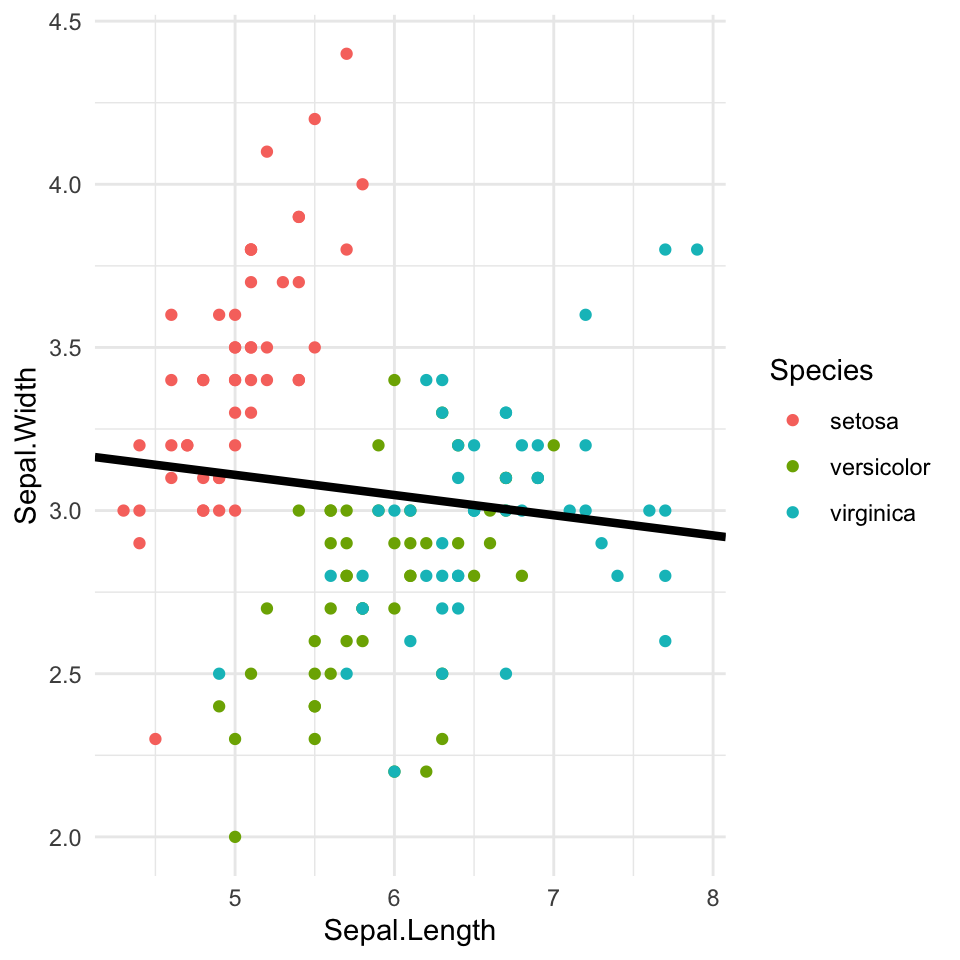

# The random intercepts model

- Mixed models allow us to relax the conditional independence
- Individual observations covary by means of shared group-level parameters

When observation $i$ is in group $j$

$$\begin{aligned}
\mathbb{E}(y_i) & = \alpha + \gamma_j + \beta X \\
y & \sim \mathcal{N}\left (\mathbb{E} \left (y \right ), \sigma \right) \\
\gamma & \sim \mathcal{N}(0, \sigma_\gamma)
\end{aligned}$$

$\gamma$ models an **offset** from the global intercept (hence prior mean of 0)

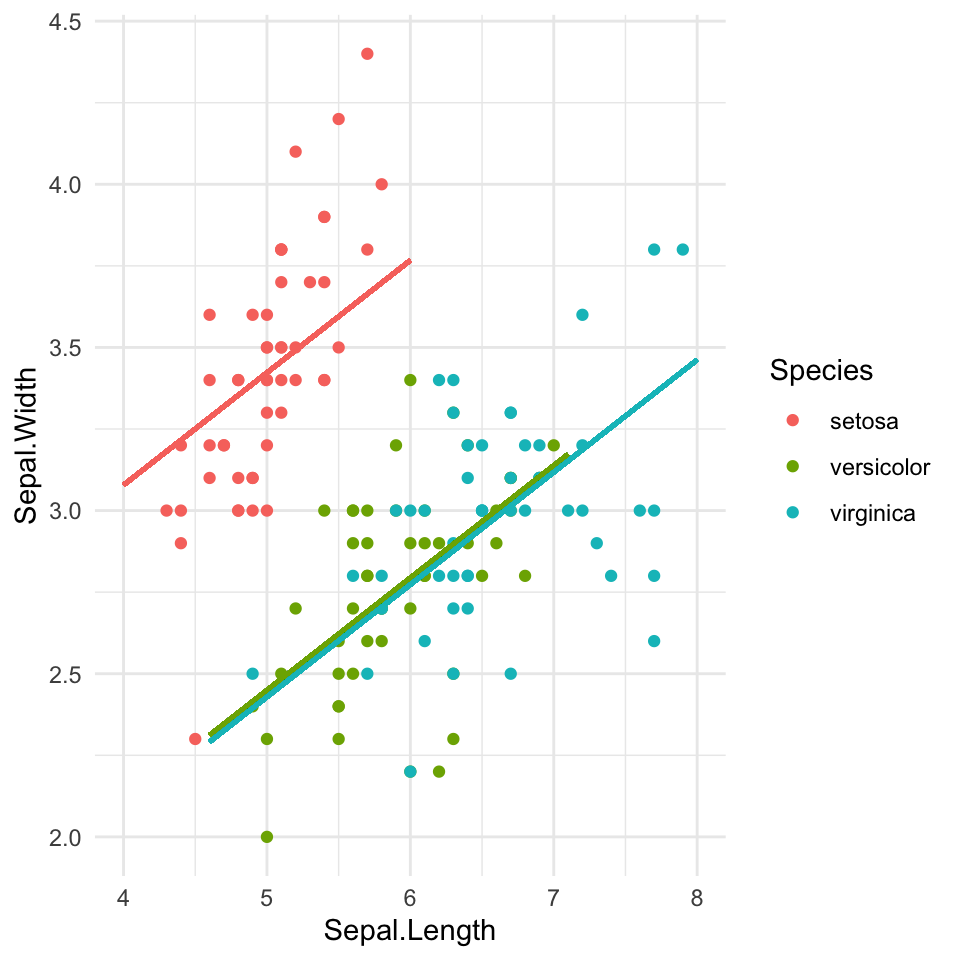

# Group membership via spatial neighbours

- We can define a hierarchical group as an observation + its neighbours
- Every data point now has a separate group and a different spatial random effect!
- We define a **neighbourhood matrix** $w$, such that $w_{ij} = 1$ if $i$ and $j$ are neighbours
- The spatial random effect of observation $i$ has a mean equal to the average spatial random effect of its neighbours
- The variance for an individual spatial unit decreases with the number of neighbours $\nu_i$

$$\begin{aligned}
\mathbb{E}(y_i) & = \alpha + \gamma_\color{red}{i} + \beta X \\
y & \sim \mathcal{N}\left (\mathbb{E} \left (y \right ), \sigma \right) \\
\gamma_i & \sim \mathcal{N} \left( \frac{\sum w_{ij} \gamma_j}{\nu_i}, \frac{\sigma_\gamma}{\nu_i} \right)
\end{aligned}$$

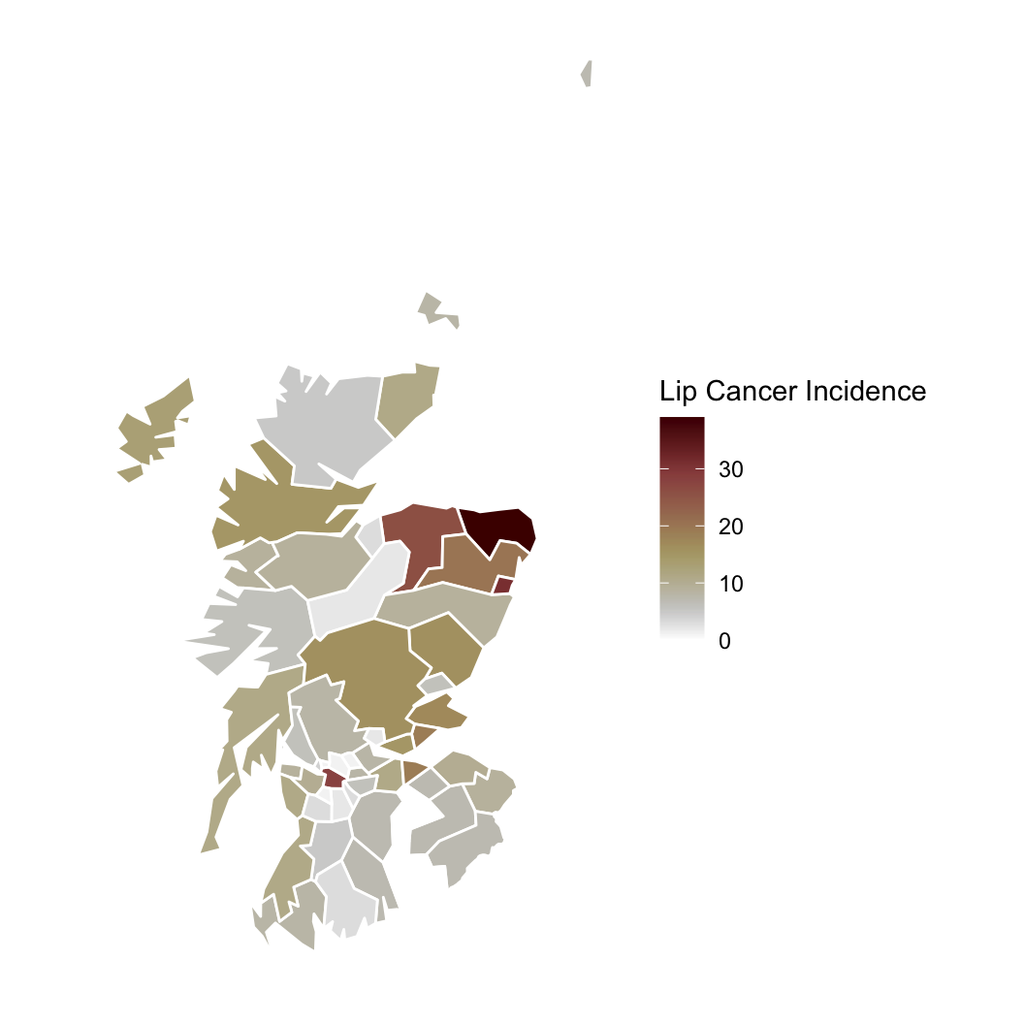

# Continuous spatial models

- With point data, all points are neighbours, but some neighbours are more important than others
- The weights matrix $w$ now has no zeros, instead we weight based on some function of the distance
- Here, I use $w_{ij} = \frac{1}{d_ij}$

$$w =
\begin{pmatrix}
Inf & 0.58 & 0.48 & 0.30 & 0.22 & 0.20 & 0.16 & 0.14 & 0.12 & 0.11 \\
0.58 & Inf & 0.75 & 0.49 & 0.32 & 0.23 & 0.20 & 0.17 & 0.14 & 0.12 \\
0.48 & 0.75 & Inf & 0.72 & 0.39 & 0.32 & 0.24 & 0.19 & 0.17 & 0.14 \\
0.30 & 0.49 & 0.72 & Inf & 0.73 & 0.37 & 0.32 & 0.24 & 0.20 & 0.16 \\
0.22 & 0.32 & 0.39 & 0.73 & Inf & 0.39 & 0.46 & 0.33 & 0.24 & 0.19 \\
0.20 & 0.23 & 0.32 & 0.37 & 0.39 & Inf & 0.52 & 0.32 & 0.30 & 0.24 \\
0.16 & 0.20 & 0.24 & 0.32 & 0.46 & 0.52 & Inf & 0.77 & 0.50 & 0.30 \\
0.14 & 0.17 & 0.19 & 0.24 & 0.33 & 0.32 & 0.77 & Inf & 0.75 & 0.35 \\
0.12 & 0.14 & 0.17 & 0.20 & 0.24 & 0.30 & 0.50 & 0.75 & Inf & 0.62 \\
0.11 & 0.12 & 0.14 & 0.16 & 0.19 & 0.24 & 0.30 & 0.35 & 0.62 & Inf \\
\end{pmatrix}$$

- This can be applied to covariance in many situations!
  - Genetic/phylogenetic relatedness
  - Temporal autocorrelation
  - Functional similarity
- Prior mixed models had **unordered** (i.e., nominal) groups
- Now the grouping variable is continuous

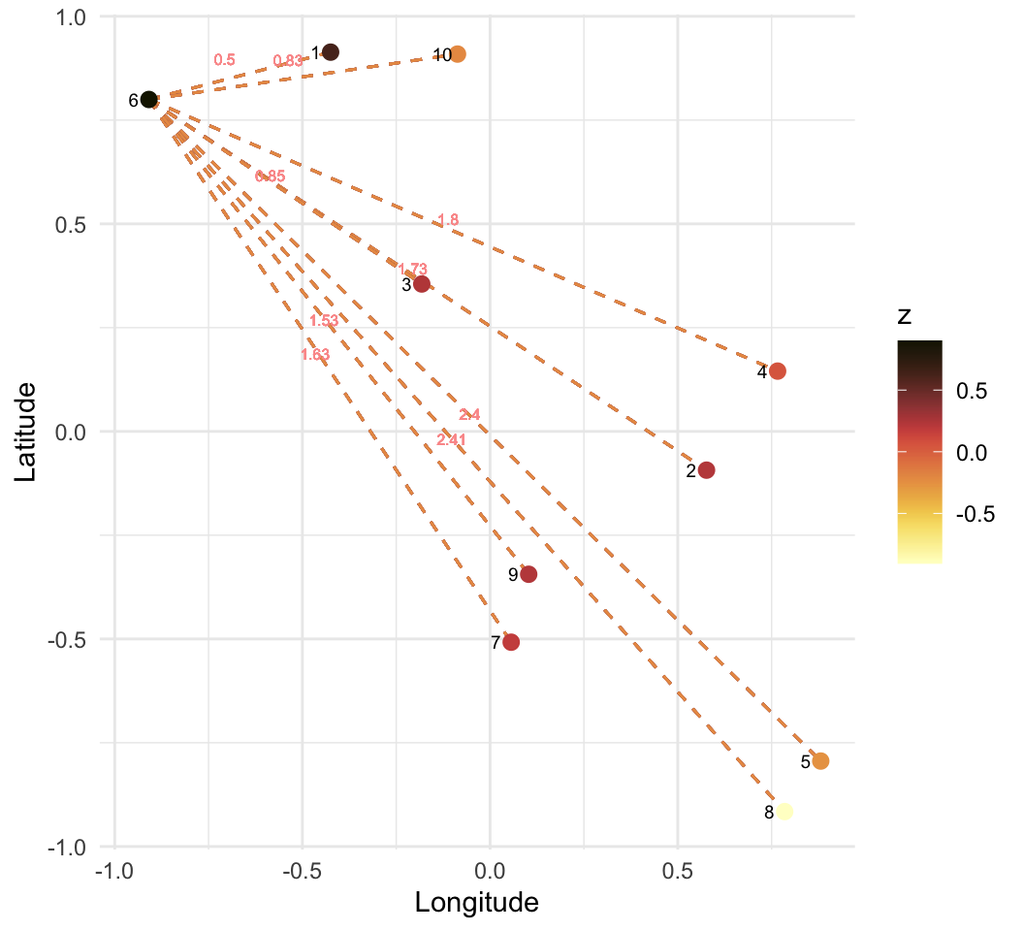

# Fully parameterized CAR

$$\begin{aligned}
\mathbb{E}(y_i) & = \alpha + \gamma_{i} + \beta X \\
y & \sim \mathcal{N}\left (\mathbb{E} \left (y \right ), \sigma \right) \\
\gamma_i & \sim \mathcal{N} \left( \frac{\sum_{j=1}^{n} w_{ij} \gamma_j}{\sum_{j=1}^{n}w_{ij}}, \sigma_\gamma \right)
\end{aligned}$$

**Problem**

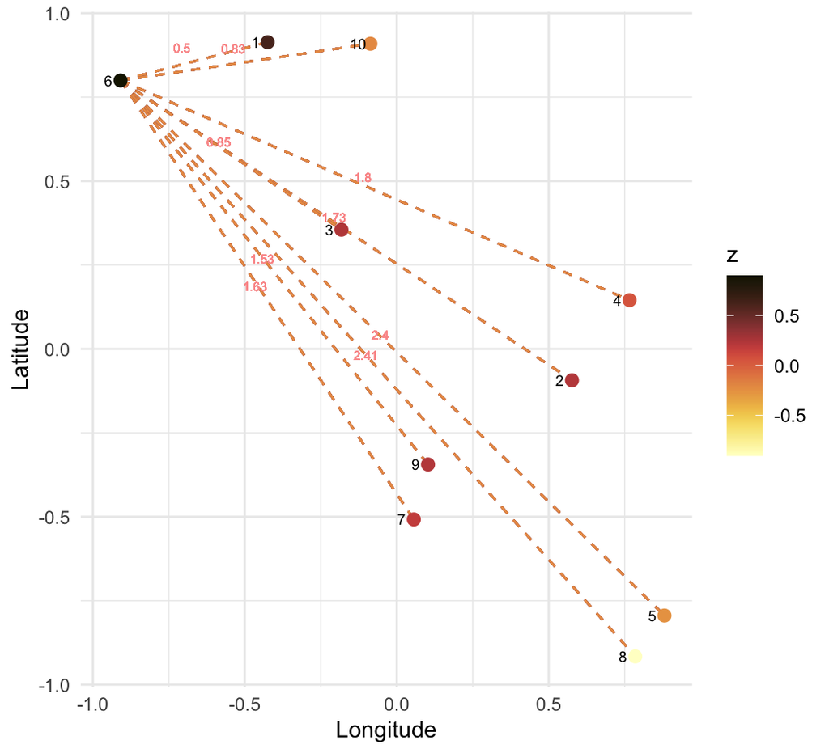

# Multivariate normal parameterization

- The previous model can be reparameterized with a multivariate normal
- The multivariate normal is parameterized with a **mean vector** and a **variance-covariance** matrix
- Diagonal elements are the variance (usually assumed to be constant for all points)
- Off diagonals are covariance between two points
- The outcomes here are the result of a **Gaussian Process**, and the model is called **GP Regression**

$$\begin{align}
\mathbb{E}(y) & = \alpha + \beta \mathbf{X} \\
y & \sim \mathcal{MN} \left( \mathbb{E}(y), \Sigma \right) \\
\Sigma_{ij} & = \frac{\rho_{ij}}{d_{ij}}
\end{align}$$

- **Note**: The GLM is a special case of a GP with covariance = 0!

# Covariance functions

- We can add a hyperparemeter layer to reduce the number of parameters we need for $\Sigma$
- In effect, we compute a regression model with $\Sigma$ as the response and the spatial (or other) distance as the predictor
- Instead of treating covariance as a **random** variable, we insert the **expectation** of this regression model (which is a deterministic function of its parameters)

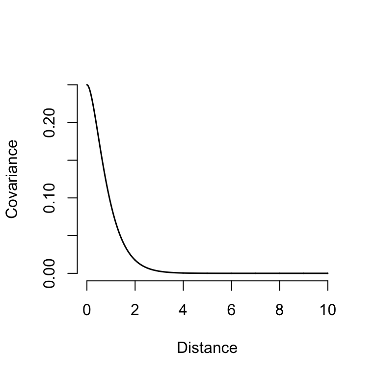

# Covariance kernel functions

- We usually use **kernel** functions to describe the shape of the covariance-distance relationship
- A common kernel for spatial models is the Matérn$^{3/2}$ function:
- $\sigma$: standard deviation
- $\rho$: lengthscale or correlation length
  - controls how quickly covariance decays with distance

$$\Sigma_{ij} = \sigma^2 \left( 1 + \frac{\sqrt{3}d_{ij}}{\rho}\right)\left(\mathrm{e}^\frac{-\sqrt{3}d_{ij}}{\rho} \right)$$

- Note that this only requires 2 hyperparameters!

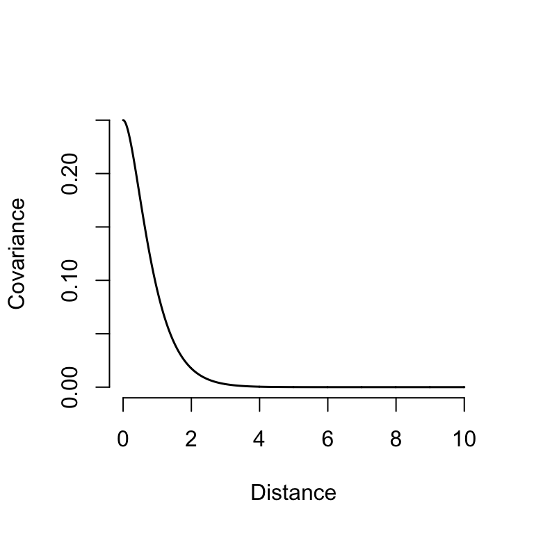

# GP GLMs

- The previous model assumed a multivariate normal for the response
- What do do when $y$ is not normal?

# GP GLMs

- The previous model assumed a multivariate normal for the response
- What do do when $y$ is not normal?
- We can reparameterize again, adding a latent variable in the form of a **Gaussian Random Field**

$$\begin{align}
\mathrm{L}[\mathbb{E}(y)] & = \alpha + \beta \mathbf{X} + \gamma \\
\theta &= \mathcal{f}[\mathbb{E}(y), \phi] \\
y & \sim \mathcal{D}(\theta) \\
\gamma & \sim \mathcal{MN} \left( \mathbf{0}, \Sigma \right) \\
\Sigma_{ij} & = \sigma^2 \left( 1 + \frac{\sqrt{3}d_{ij}}{\rho}\right)\left(\mathrm{e}^\frac{-\sqrt{3}d_{ij}}{\rho} \right)
\end{align}$$

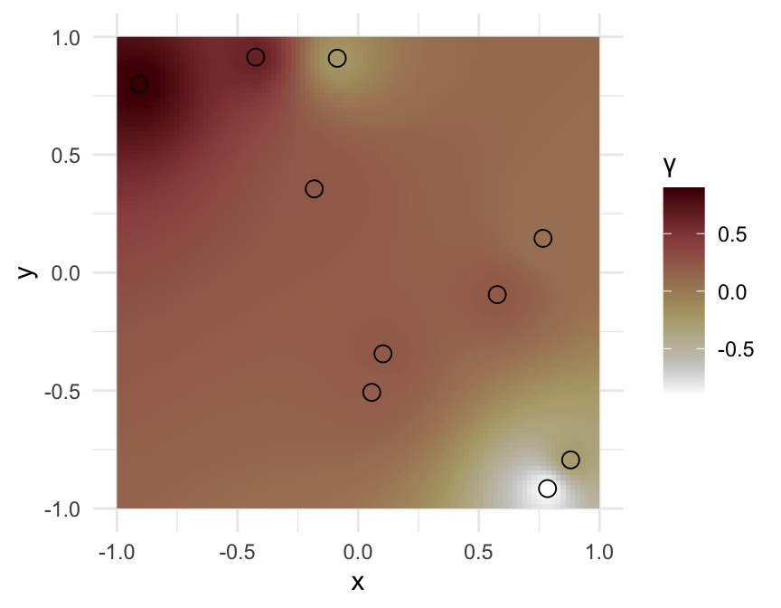

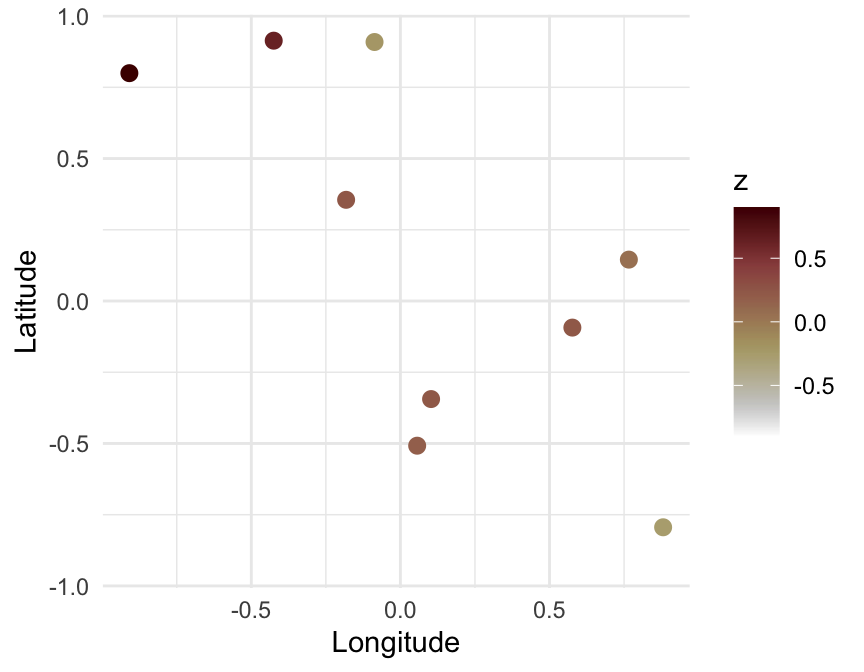

# Implementation

- The GP in Stan generally performs well
- Feasible for up to several hundred data points
- We add a `functions` block before `data` to implement our covariance function
- We pass a coordinate matrix to stan, then compute distance weights
- We employ a few “tricks” to keep the model numerically stable

# Implementation

```stan
functions {
    matrix matern_cov (matrix dist, real rho, real sigma, real delta) {
        int NR = rows(dist);
        matrix [NR,NR] result;

        for(i in 1:(NR-1)) {
            result[i,i] = sigma^2 + delta;
            for(j in (i+1):NR) {
                real mpar = (sqrt(3.0) * dist[i,j])/(rho);
                result[i,j] = sigma^2 * (1 + (mpar)) * (exp(-1*mpar));
                result[j,i] = result[i,j];
            }
        }
        result[NR,NR] =  sigma^2 + delta;
        return(result);
    }
}
data {
    int <lower=1> n; // number of sites
    int <lower=1> k; // number of predictors for the non-spatial process

    vector [n] y; // response
    matrix [n,k] x; // predictor variables
    matrix [n,2] coords; // spatial coordinates, x first, then y
}
transformed data {
    // this is a fairly memory-intensive parameterisation
    // with large datasets, other parameterisations will be needed
    // we only fill in the upper triangle, we only need that part of the matrix
    matrix [n,n] d; // euclidean distance matrix
    real delta = 1e-9; // small addition to prevent numerical problems

    for(i in 1:(n-1)) {
        for(j in (i+1):n) {
            d[i,j] = sqrt((coords[i,1] - coords[j,1])^2 + (coords[i,2] - coords[j,2])^2);
        }
    }
}
parameters {
    // hyperparameters
    real <lower=0> rho; // spatial process lengthscale
    real <lower=0> sigma; // error term in VCV matrix
    real <lower=0> sig_y; //gaussian error term for y

    // regression parameters
    real alpha;
    vector [k] beta;

    // scaled latent GP effect
    vector [n] eta;
}
transformed parameters {
    vector [n] mu; // expectation of y
    {
        // compute variance-covariance matrix due to euclidean distance
        matrix[n, n] Sig; // variance-covariance matrix
        matrix[n, n] L_Sig; // cholesky decomposition of VCV matrix
        vector [n] gamma; // additive effect of GP, at response scale

        Sig = matern_cov(d, rho, sigma, delta);
        L_Sig = cholesky_decompose(Sig);
        gamma = L_Sig * eta;
        mu = alpha + x * beta + gamma;
    }
}
model {
    rho ~ inv_gamma(5, 5);
    alpha ~ normal(0, 10);
    beta ~ normal(0, 5);
    sigma ~ normal(0, 5);
    eta ~ std_normal();

    y ~ normal(mu, sig_y);
}
```